# C037 Expanding NCBI blastp analysis

Bin He

2022-04-08 updated 2022-09-22

```r
suppressPackageStartupMessages(require(tidyverse))
suppressPackageStartupMessages(require(cowplot))
suppressPackageStartupMessages(require(ggvenn))
suppressPackageStartupMessages(require(seqinr))
# set NCBI Entrez API key
suppressPackageStartupMessages(require(rentrez))
set_entrez_key("f4f01c220f3a0a162bada5b0bd5d4b131908")
```

## Background

This analysis is in response to reviewer 1’s questions:

1. The submitted version used *C. auris* Hil1’s PF11765 domain as the query (bait). What if other homologs were used? Would the number and identity of the blast results change?
2. Why remove species from the blast output?

To address the first problem, I did blastp with two additional queries: the PF11765 domains in *C. albicans* Hyr1 and *C. glabrata* Hyr1.

As for the second question, my response and solutions are to include any species that were among the Y1000 tree in Shen et al. 2018. The more complete set can be used for the family expansion analysis. I plan to keep the homologs analysis restricted to the 104 homologs, as adding more species are not expected to change the main conclusions.

## Data

I performed blastp analysis using the three queries against either the refseq_prot, the new clustered nr databases or in FungiDB. For the former two (performed through web interface on NCBI website), I downloaded the results using the Request ID (RID) with the `blast_formatter` program and then used the same tool to reformat the output to contain the desired columns. For the FungiDB result, I tried downloading the results in ASN.1 format, but wasn’t able to use `blast_formatter` to reformat it. Therefore I downloaded the table as shown on the default result page.

```r
# header for ncbi output
header <- c("query", "qcovs", "sid", "slen", "pident", "q.start", "q.end", "s.start", "s.end", "evalue", "staxid", "sscinames")
# refseq results
refseq <- read_tsv("data/20220406-expanded-PF11765-blastp-refseq.txt", comment = "#", col_types = cols(), col_names = header) %>%
  mutate(species = word(sscinames, 1, 2) %>% gsub("\\[|\\]", "", x = .), strain = word(sscinames, 3, -1),
         pident = num(pident, digits = 1)) %>%
  select(-sscinames) %>%
  relocate(species:strain, .after = pident)
# nr results
nr <- read_tsv("data/20220406-expanded-PF11765-blastp-clusternr.txt", comment = "#", col_types = cols(), col_names = header) %>%
  mutate(species = word(sscinames, 1, 2) %>% gsub("\\[|\\]", "", x = .), strain = word(sscinames, 3, -1),
         pident = num(pident, digits = 1)) %>%
  select(-sscinames) %>%
  relocate(species:strain, .after = pident)
# fungidb results
fdb <- read_csv("data/20220427-expanded-blast-fungidb.csv") %>%
  rename(sid = Accession, evalue = `E-Value`, score = Score, alen = `Align Length`, qcovs = `Query Coverage`) %>%
  mutate(
    species = word(Organism, 1, 2) %>% gsub("\\[|\\]", "", x = .), strain = word(Organism, 3, -1),
    query = word(Query, 1, 1),
    pident = num(Identity*100, digits = 1),
    qcovs = num(qcovs*100, digits = 0),
    evalue = signif(evalue, digits = 1),
    score = signif(score, digits = 3),
    .keep = "unused"
  ) %>%
  # make spelling consistent with ncbi
  mutate(species = gsub("Candida haemulonis", "Candida haemuloni", species)) %>%
  select(query, qcovs, sid, pident, species, strain, score, evalue, `Rank Per Query`, `Rank Per Subject`)
```

## Analysis

### 1. Overlap between the three queries?

What’s the extent of overlap between the blastp hits using the three different queries?

Hits with <50% query coverage are removed.

```r
refseq %>% filter(qcovs < 50)
```

| query | qcovs | sid | slen | pident | species | strain | q.start | q.end | s.start | s.end | evalue | staxid |
| --- | --- | --- | --- | --- | --- | --- | --- | --- | --- | --- | --- | --- |
| Caur_Hil1 | 25 | ref\|WP_146232083.1\| | 91 | 92.4 | Pseudomonas syringae;Pseudomonas | syringae pv. pisi | 2 | 80 | 13 | 91 | 3.75e-38 | 317;59510 |
| Caur_Hil1 | 49 | ref\|XP_003958004.1\| | 893 | 32.5 | Kazachstania africana | CBS 2517 | 151 | 307 | 230 | 374 | 2.00e-08 | 1071382 |
| Caur_Hil1 | 45 | ref\|XP_002550902.1\| | 878 | 32.7 | Candida tropicalis | MYA-3404 | 158 | 300 | 23 | 174 | 2.55e-07 | 294747 |
| Calb_Hyr1 | 48 | ref\|XP_002550902.1\| | 878 | 38.4 | Candida tropicalis | MYA-3404 | 161 | 317 | 23 | 186 | 1.05e-25 | 294747 |
| Calb_Hyr1 | 49 | ref\|XP_037000023.1\| | 350 | 29.4 | Artibeus jamaicensis | NA | 160 | 319 | 11 | 175 | 7.82e-08 | 9417 |

Venn diagram showing the extent of overlap and set specific hits:

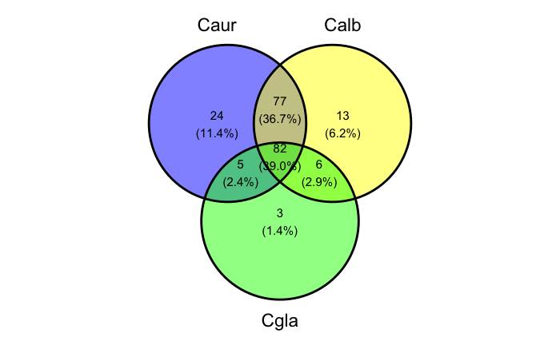

```r
set.ovlp <- refseq %>%
  filter(qcovs >= 50) %>%
  group_by(sid) %>%
  summarize(
    Caur = any(query == "Caur_Hil1"),
    Calb = any(query == "Calb_Hyr1"),
    Cgla = any(query == "Cgla_Hyr1")
  )
ggvenn(set.ovlp)
```

Which genes are found by the *C. albicans* and/or *C. glabrata* Hyr1 query blast but not by the *C. auris* Hil1 query blast?

```r
Calb.not.Caur.hits <- set.ovlp %>% filter(!Caur) %>% pull(sid)
refseq %>% filter(sid %in% Calb.not.Caur.hits) %>%
  group_by(sid) %>% filter(evalue == min(evalue)) %>% ungroup() %>%
  select(query, qcovs, sid, slen, pident, evalue, species) %>%
  mutate(species = paste(str_sub(species, 1, 1), word(species, 2, 2), sep = ". ")) %>%
  arrange(species)
```

| query | qcovs | sid | slen | pident | evalue | species |
| --- | --- | --- | --- | --- | --- | --- |
| Cgla_Hyr1 | 55 | ref\|XP_037000023.1\| | 350 | 100.0 | 6.07e-120 | A. jamaicensis |
| Calb_Hyr1 | 91 | ref\|XP_002999585.1\| | 3241 | 28.9 | 5.24e-08 | C. glabrata |
| Calb_Hyr1 | 54 | ref\|XP_020068387.1\| | 935 | 29.0 | 6.40e-10 | C. jadinii |
| Calb_Hyr1 | 98 | ref\|XP_002615218.1\| | 1442 | 29.0 | 2.37e-14 | C. lusitaniae |
| Calb_Hyr1 | 64 | ref\|XP_002620045.1\| | 231 | 26.7 | 2.86e-11 | C. lusitaniae |
| Calb_Hyr1 | 64 | ref\|XP_002614121.1\| | 1143 | 28.8 | 3.28e-10 | C. lusitaniae |
| Calb_Hyr1 | 97 | ref\|XP_036665262.1\| | 1640 | 37.1 | 5.89e-43 | C. parapsilosis |
| Calb_Hyr1 | 82 | ref\|XP_036662815.1\| | 1429 | 35.7 | 7.47e-27 | C. parapsilosis |
| Calb_Hyr1 | 82 | ref\|XP_036665263.1\| | 2273 | 35.5 | 4.86e-20 | C. parapsilosis |
| Calb_Hyr1 | 63 | ref\|XP_003956397.1\| | 286 | 25.0 | 8.05e-06 | K. africana |

[output cut: 12 more lines]

Among the species included previously, how many of the “new” sequences were not part of the 104 homologs list?

| sid | gid | species | in_early_verion | source |
| --- | --- | --- | --- | --- |
| XP_002999585 | CAGL0L00227g | C. glabrata | Yes | GRYC |
| XP_002615218 | CLUG_05233 | C. lusitaniae | Yes | FungiDB |
| XP_002620045 | CLUG_01204 | C. lusitaniae | No^ | NA |
| XP_002614121 | CLUG_05607 | C. lusitaniae | No | NA |
| XP_036665262 | CPAR2_806390 | C. parapsilosis | Yes | FungiDB |
| XP_036662815 | CPAR2_600430 | C. parapsilosis | Yes | FungiDB |
| XP_036665263 | CPAR2_806400 | C. parapsilosis | No | NA |
| XP_452176 | KLLA0_B14498g | K. lactis | Yes | GRYC |
| XP_001527307 | LELG_02136 | L. elongisporus | No | NA |
| XP_001385683 | PICST_3402 | S. stipitis | No^ | NA |
| XP_001383953 | PICST_31095 | S. stipitis | Yes* | NCBI |

*this hit was originally included when the N560 aa was used as query. In later analysis where N360 aa (of *C. auris* Hil1) was used as query, this hit dropped off the list due to E-value being above the 1e-5 cutoff. So it is a legit, but borderline hit.

^shorter than 500 a.a.

> Five hits are new, among which two are shorter than 500 a.a. and would have been excluded from the list (although they were not identified at all with the *C. auris* query).

### 2. Species to include

The new criteria is whether the species is among the 332 included in the large-scale phylogeny of Shen *et al.* 2018. I downloaded the tree from https://github.com/JLSteenwyk/treehouse/blob/master/Data/Saccharomycotina_fig2_Shen_etal_2018.tre and manually converted it into a list of species names.

```r
shen2018 <- scan("../../data/yeast-phylogeny/Saccharomycotina_fig2_Shen_etal_2018.txt", what = "character", sep = "\n")
```

Any species in the refseq hit list not in the Shen 2018 phylogeny?

```r
setdiff(unique(refseq$species), shen2018)
```

```
 [1] "Candida haemuloni"                "Candida duobushaemulonis"         "Candida pseudohaemulonii"
 [4] "Suhomyces tanzawaensis"           "Pseudomonas syringae;Pseudomonas" "Diutina rugosa"
 [7] "Yamadazyma tenuis"                "Schizosaccharomyces cryophilus"   "Kazachstania barnettii"
[10] "Artibeus jamaicensis"
```

| refseq_name | taxid | in_Shen_2018 | shen2018_name |
| --- | --- | --- | --- |
| Candida haemuloni | 45357 | No | NA |
| Candida duobushaemulonis | 1231522 | No | NA |
| Candida pseudohaemulonii | 418784 | No | NA |
| Suhomyces tanzawaensis | 984487 | Yes | Candida tanzawaensis |
| Pseudomonas syringae:Pseudomonas | 317;59510 | No | NA |
| Diutina rugosa | 5481 | No | NA |
| Yamadazyma tenuis | 590646 | Yes | Candida tenuis |
| Schizosaccharomyces cryophilus | 653667 | No | NA |
| Kazachstania barnettii | 61262 | No | NA |
| Artibeus jamaicensis | 9417 | No | NA |

Manually figure out species synonyms and record both names for the species to use. **update**: downloaded the species name convertion table from Shen et al 2018 supplementary material.

```r
spsNameConvert <- read_tsv("../../data/yeast-phylogeny/343taxa_speicies-name_clade-name_color-code.txt", col_types = cols()) %>%
  mutate(species = word(`Species name`, 1, 2))
spsNameSyn <- tibble(
  ncbi.name = c(intersect(refseq$species, shen2018), "Suhomyces tanzawaensis", "Yamadazyma tenuis", "Lachancea kluyveri"),
  shen.name = c(intersect(refseq$species, shen2018), "Candida tanzawaensis", "Candida tenuis", "Lachancea kluyveri")
)
```

### 3. Check protein completeness

Our goal is to create a table documenting the number of putative homologs per species. We used to apply a length cutoff of 500 aa. However, the specific value of the cutoff is not based on any comprehensive studies. This combined with the uncertainty in some putative homolog’s length due to assembly issues led us to reconsider this filter. The solution we came up with is to include all blast hits based on the PF11765 domain alone in the family expansion analysis (CAFE and phylogenetic reconstruction). Later we will selectively include some of them for the protein feature analysis. Since the latter analysis is mainly to demonstrate the fast evolution of the central domain features, it doesn’t rely on the completeness of the Hil family or the inclusion of all species for which we have records for.

In curating the blast hits, we found that some (protein) blast hits are annotated as missing the carboxy terminus. This would prevent us from properly assessing the length of the protein. Note that “incomplete” means different things for the protein vs mRNA record. For the latter, “incomplete” could mean missing 5’ and/or 3’UTR while the CDS may be complete. A large number of the mRNA records corresponding to the protein hits in the list are “partial”. That’s not reason for exclusion.

For *C. tropicalis*, I found a new, [2019 assembly](https://www.ncbi.nlm.nih.gov/assembly/GCA_013177555.1) that uses both PacBio and Illumina. The assembly did use the reference genome assembly as a guide.

To identify all partial mRNA, we will use the `rentrez` package to query the ncbi database.

```r
# define a function for retrieving the mRNA information from the nucleotide databased, based on protein ID
retrieve_mrna_info <- function(ids){
  nuc.lnk <- entrez_link(dbfrom = "protein", db = "nucleotide", id = ids, by_id = TRUE)
  nucID <- sapply(nuc.lnk, function(x){
    lnk = x$links$protein_nuccore_mrna
    return(ifelse(is.null(lnk), NA, lnk))
  })
  nucSum <- entrez_summary(db = "nuccore", id = na.omit(nucID))
  names(nucSum) <- ids[!is.na(nucID)]
  return(nucSum)
}

retrieve_protein_info <- function(ids){
  pSum <- entrez_summary(db = "protein", id = ids)
  names(pSum) <- ids
  return(pSum)
}
```

```r
# all refseq protein IDs to get the mRNA information for
pid <- unique(refseq$sid)
# posting too many queries can hit the rate-limit. split into multiples of 50s
iter.pid <- split(x = pid, f = ceiling(seq_along(pid)/50))
pSum <- sapply(iter.pid, retrieve_protein_info)
nucSum <- sapply(iter.pid, retrieve_mrna_info)
```

```r
# extract the mRNA info
mrnaInfo <- lapply(nucSum, function(x) {
  extract_from_esummary(x, elements = c("caption", "completeness"), simplify = FALSE) %>%
    bind_rows(.id = "sid") %>%
    rename(tID = caption, tComplete = completeness)
}) %>% bind_rows()
# extract the protein completeness info
pInfo <- lapply(pSum, function(x) {
  extract_from_esummary(x, elements = c("completeness"), simplify = FALSE) %>%
    bind_rows(.id = "sid") %>%
    rename(pComplete = completeness)
}) %>% bind_rows()
```

Now remove duplicates (resulting from the different queries) and filter by species (those that overlap the Shen 2018 list plus the MDR clade)

```r
sps.include <- c(spsNameSyn$ncbi.name, "Candida haemuloni", "Candida duobushaemulonis", "Candida pseudohaemulonii")
dedup.ref <- refseq %>%
  filter(species %in% sps.include, qcovs >= 50) %>%
  group_by(sid) %>%
  filter(evalue == min(evalue)) %>%
  left_join(mrnaInfo, by = c("sid" = "sid")) %>%
  left_join(pInfo, by = c("sid" = "sid")) %>%
  select(query, sid, slen, pComplete, tID, tComplete, species, strain, everything())
```

Summarize the deduplicated list - for each species, record the total number of hits, those that are labeled as incomplete in the protein record, those that are above 500 aa and the number of hits below 500 aa that are labeled as incomplete

```r
sum.ref <- dedup.ref %>%
  group_by(species, strain) %>%
  summarize(
    total = n(),
    incompl = sum(pComplete != ""),
    gt500 = sum(slen >= 500),
    shortIncompl = sum(pComplete != "" & slen < 500)
  )
sum.ref %>% arrange(desc(shortIncompl))
```

| species | strain | total | incompl | gt500 | shortIncompl |
| --- | --- | --- | --- | --- | --- |
| Scheffersomyces stipitis | CBS 6054 | 18 | 15 | 5 | 12 |
| Metschnikowia bicuspidata | var. bicuspidata NRRL YB-4993 | 29 | 10 | 2 | 10 |
| Suhomyces tanzawaensis | NRRL Y-17324 | 4 | 3 | 1 | 3 |
| Yamadazyma tenuis | ATCC 10573 | 4 | 2 | 0 | 2 |
| Cyberlindnera jadinii | NRRL Y-1542 | 2 | 1 | 1 | 1 |
| Debaryomyces fabryi | NA | 1 | 1 | 0 | 1 |
| Candida albicans | SC5314 | 12 | 0 | 12 | 0 |
| Candida auris | NA | 7 | 0 | 7 | 0 |
| Candida dubliniensis | CD36 | 11 | 0 | 11 | 0 |
| Candida duobushaemulonis | NA | 11 | 11 | 11 | 0 |

[output cut: 16 more lines]

> - *S. stipitis* and *M. bicuspidata* had a large number of incomplete proteins, likely a reflection of the genome assembly status. For *M. bicuspidata*, a newer Illumina + Oxford Nanopore [assembly](https://www.ncbi.nlm.nih.gov/assembly/GCA_022575955.1/) is available for this species but is only assembled to the contig level, with no gene annotation. I tried blasting the refseq hits from the species against the new assembly but the match was poor for most of the hits - instead of getting a long, contiguous HSP, I got mostly broken pieces with lots of mismatches. I suspect this is due to a combination of tandem gene arrays causing difficulty for assembly around the Hil homologs loci and the sequencing depth and assembly itself. Based on these observations, I plan to include the species in the CAFE analysis and potentially in the phylogenetic reconstruction as well, but exclude it from the homolog protein trait analyses.
> - For *S. stipitis*, I identified a [newer assembly](https://www.ncbi.nlm.nih.gov/assembly/GCA_016859295.1/) for a different strain (NRRL Y-7124) and performed local blast against the annotated protein sequences. I identified a total of 13 hits, of which seven are above the 50% query coverage threshold. This is quite different from the 18 hits identified in the refseq assembly. When I blasted the refseq hits against the new assembly, some of them had poor matches. Without further investigation, it is not clear what is the cause of the discrepancy. I plan to use the new assembly hits for downstream analyses given that it is more recently sequenced.
> - For the same reasons as above, I plan to include *Y. tenuis*, *S. tanzawaensis* and *C. jadinii* in the CAFE analysis but exclude them from the protein feature analyses. Given that they have relatively few hits, I could consider manually searching for the full length ORF, but that’s optional.
> - For *D. fabryi*, the Y-1000 plus project has sequenced another strain from this species. I blasted against that assembly and identified two matches. But the two hits appear too similar to each other, leaving me wonder if they are truly distinct loci, or are they partially duplicate contigs.

Hits based on the new *S. stipitis* assembly

```r
s.stipitis <- read_tsv("../../data/long-read-assemblies/s_stipitis_NRRL_Y7124/S-stipitis-NRRL-Y7124-Hil-homologs-blast.txt",
                       comment = "#", col_names = header[1:10], col_types = cols()) %>%
  mutate(species = "Scheffersomyces stipitis", strain = "NRRL Y-7124", staxid = "913138",
         pident = num(pident, digits = 1)) %>%
  relocate(species:strain, .after = pident) %>%
  group_by(sid) %>%
  filter(evalue == min(evalue))
```

### 4. *Candida glabrata* hits

The Cormack lab released new assemblies for a couple of *C. glabrata* strains in Xu 2020 and Xu 2021 (PMIDs: 32068314, 33713372). These assemblies were based on long-red sequencing technologies supplemented with short reads for polishing the sequences. They also paid special attention to the subtelomeres, using various means to verify that their newly assembled subtelomeric regions are correct. Performing blastp searches against these assemblies (I tested two of them: ATTC2001=CBS138 and BG2) recovered 13 instead of 3 hits (in the new refseq hit list). I verified that all of them are credible. Actually, Xu *et al.* 2020 supplementary table specifically listed these 13 as predicted adhesins belonging to cluster V, which also included Awp2 studied by Reithofer et al 2021. Including them in the homologs list would properly reflect the family size in the species, but will also highlight the issue that incompletely assembled subtelomeres may have led to many false negatives in the gene family inventory. I think it is worth including it and commenting on the caveats.

```r
c.glabrata <- read_tsv("../../data/long-read-assemblies/c_glabrata_CBS138/C-glabrata-CBS138-Hil-homologs-blast.txt",
                       comment = "#", col_names = header[1:10], col_types = cols()) %>%
  mutate(species = "Candida glabrata", strain = "CBS 138", staxid = "5478",
         pident = num(pident, digits = 1)) %>%
  relocate(species:strain, .after = pident) %>%
  group_by(sid) %>%
  filter(evalue == min(evalue))# %>%
  #rename(pid = sid)

c.glabrata
```

| query | qcovs | sid | slen | pident | species | strain | q.start | q.end | s.start | s.end | evalue | staxid |
| --- | --- | --- | --- | --- | --- | --- | --- | --- | --- | --- | --- | --- |
| Cgla_Hyr1 | 100 | gb\|QHS65613.1\| | 965 | 100.0 | Candida glabrata | CBS 138 | 1 | 328 | 14 | 341 | 0.00e+00 | 5478 |
| Cgla_Hyr1 | 99 | gb\|QHS67215.1\| | 1861 | 52.3 | Candida glabrata | CBS 138 | 4 | 328 | 15 | 333 | 1.77e-104 | 5478 |
| Cgla_Hyr1 | 96 | gb\|QHS67886.1\| | 2111 | 31.7 | Candida glabrata | CBS 138 | 11 | 326 | 28 | 336 | 3.87e-25 | 5478 |
| Cgla_Hyr1 | 99 | gb\|QHS67369.1\| | 2385 | 31.5 | Candida glabrata | CBS 138 | 3 | 326 | 20 | 336 | 2.68e-24 | 5478 |
| Cgla_Hyr1 | 96 | gb\|QHS67887.1\| | 832 | 30.7 | Candida glabrata | CBS 138 | 13 | 326 | 29 | 335 | 6.25e-23 | 5478 |
| Cgla_Hyr1 | 95 | gb\|QHS68452.1\| | 3241 | 29.7 | Candida glabrata | CBS 138 | 11 | 322 | 28 | 333 | 7.05e-23 | 5478 |
| Cgla_Hyr1 | 95 | gb\|QHS66001.1\| | 1570 | 31.4 | Candida glabrata | CBS 138 | 11 | 322 | 48 | 359 | 1.35e-22 | 5478 |
| Cgla_Hyr1 | 99 | gb\|QHS69029.1\| | 1580 | 29.2 | Candida glabrata | CBS 138 | 1 | 326 | 18 | 336 | 7.63e-20 | 5478 |
| Cgla_Hyr1 | 99 | gb\|QHS64595.1\| | 955 | 29.2 | Candida glabrata | CBS 138 | 1 | 326 | 6 | 324 | 7.24e-19 | 5478 |
| Cgla_Hyr1 | 95 | gb\|QHS64811.1\| | 2231 | 28.4 | Candida glabrata | CBS 138 | 11 | 322 | 28 | 334 | 1.41e-18 | 5478 |

[output cut: 3 more lines]

Note that I also checked three other species for which I can find a recent assembly that used long-read technlogoies. None of them led to so many more hits as the *C. glabrata* assembly did. In fact, only the *C. nivariensis* assembly yielded one more hit than the older, short-read based assembly. There may be two possibilities: 1) not all new assemblies are created equal. there are some special properties of the *C. glabrata* assembly that made its subtelomeric regions especially well assembled; 2) there is something special about *C. glabrata* in that the Hil family expanded more significantly than even the closely related Nakaseomyces species. As of now we cannot distinguish between these two.

### 5. FungiDB hits

FungiDB doesn’t include any species not already in the refseq database. The hits that were added to the refseq hits from the earlier analysis are

```r
prev.fdb.add <- tribble(
  ~gid, ~pid, ~species,
  "CLUG_05233", "XP_002615218.1", "Clavispora lusitaniae",
  "CPAR2_600430", "XP_036662815.1", "Candida parapsilosis",
  "CPAR2_806390", "XP_036665262.1", "Candida parapsilosis",
  "CPAR2_806420", "XP_036665265.1", "Candida parapsilosis",
  "B9J08_004098", "PIS52481.1", "Candida auris"
)
prev.fdb.add %>% filter(!pid %in% dedup.ref$sid)
```

| gid | pid | species |
| --- | --- | --- |
| CLUG_05233 | XP_002615218.1 | Clavispora lusitaniae |
| CPAR2_600430 | XP_036662815.1 | Candida parapsilosis |
| CPAR2_806390 | XP_036665262.1 | Candida parapsilosis |
| CPAR2_806420 | XP_036665265.1 | Candida parapsilosis |
| B9J08_004098 | PIS52481.1 | Candida auris |

> The first four are not missing, just a difference in the ID format. The missing *C. auris* sequence is known to us and will be added regardless. Based on the above, we will no longer consult the FungiDB to supplement the refseq hits.

```r
c.auris <- read_tsv("../../output/XP_028889033-Cauris-five-strains-blast.txt",
                    comment = "#", col_types = cols()) %>%
  filter(qseqid == "XP_028889033.1_PF11765", sseqid == "PIS52481.1") %>%
  rename(sid = sseqid) %>%
  mutate(
    pid = sid,
    query = "Caur_Hil1",
    # the blast result from the above file was done using the first 325 amino acids as query
    # I manually did two sequence blast with the PF11765 from Hil1 as the query and entered
    # the query and subject start and end positions below
    q.start = 12, q.end = 326, s.start = 11, s.end = 325,
    qcovs = (q.end - q.start + 1)/325*100,
    slen = 1247,
    species = "Candida auris",
    staxid = "498019"
  ) %>%
  select(query, sid, slen, species, qcovs, pident, q.start, q.end, s.start, s.end, evalue, staxid, pid)
```

I now consider the refseq list complete, we will gather the final list of IDs and retrieve their sequences.

Retrieve protein info (no mRNA information is available)

```r
id.add <- c(c.glabrata$sid, s.stipitis$sid, c.auris$sid)
pSum1 <- retrieve_protein_info(id.add)
# extract the protein completeness info
pInfo1 <- extract_from_esummary(pSum1, elements = c("completeness"), simplify = FALSE) %>%
    bind_rows(.id = "sid") %>%
    rename(pComplete = completeness)
```

Replace *C. glabrata* and *S. stipitis* in refseq hit list. Add the *C. auris* Hil4 from B8441.

```r
dedup.ref.cg <- dedup.ref %>%
  filter(!species %in% c("Candida glabrata", "Scheffersomyces stipitis")) %>%
  bind_rows(filter(s.stipitis, qcovs >= 50)) %>%
  bind_rows(filter(c.glabrata, qcovs >= 50)) %>%
  bind_rows(filter(c.auris, qcovs >= 50)) %>%
  rows_update(pInfo1, by = "sid", unmatched = "ignore") %>%
  mutate(pid = gsub(".*\\|(.*)\\|.*", "\\1", sid))
```

Retrieve sequences

```r
iter.pid1 <- split(x = dedup.ref.cg$pid, f = ceiling(seq_along(dedup.ref.cg$pid)/50))
ref.seq <- lapply(iter.pid1, function(x){
  entrez_fetch(db = "protein", id = x, rettype = "fasta")
})
```

```r
# merge all the sequences and write to file
ref.seq %>% paste0(collapse = "") %>%
  write(file = "../../output/20220503-expanded-blast-refseq-homologs.faa")
```

### 6. GRYC hits

GRYC did include a few more species, especially in the Nakaseomyces and Lachancea genera. While the same assembly data appear to exist in the ncbi database, they are certainly not included in the refseq database. Moreover, even when the assemblies are present in the ncbi database, there are only the genomic sequences, not translated CDS, which likely make them unavailable to blastp searches. Therefore I downloaded the five non-glabrata Nakaseomyces genomes plus one Lachancea species, *L. kluyveri* and performed local `tblastn` searches. Below I will process the results and decide which ones to include in the final list.

```r
gryc.sps <- tribble(
  ~sps.abr, ~species, ~strain, ~staxid,
  "CANI", "Candida nivariensis", "CBS 9983", "1279115",
  "NADE", "Nakaseomyces delphensis", "CBS 2170", "1279113",
  "NABA", "Nakaseomyces bacillisporus", "CBS 7720", "1279116",
  "CACA", "Candida castellii", "CBS 4332", "1279086",
  "CABR", "Candida bracarensis", "CBS 10154", "1279114",
  "SAKL", "Lachancea kluyveri", "CBS 3082", "4934"
)

gryc <- read_tsv("../../data/Nakaseomyces_GRYC/Nakaseomyces-Hil-homologs-blast.txt",
                       comment = "#", col_names = header[1:10], col_types = cols()) %>%
  mutate(sps.abr = gsub("BN[0-9]*_", "", sid) %>% str_sub(1,4), pident = num(pident, digits = 1)) %>%
  left_join(gryc.sps, by = "sps.abr") %>%
  relocate(species:strain, .after = pident) %>%
  select(-sps.abr)

dedup.gryc <- gryc %>%
  group_by(sid) %>%
  filter(evalue == min(evalue)) %>%
  mutate(pid = gsub("BN[0-9]*_", "", sid) %>% gsub("1_1$", "", .)) %>%
  filter(qcovs >= 50) %>%
  ungroup()
```

Extract the protein sequences from the combined fasta

```r
cat(dedup.gryc$sid, file = "20220506-gryc-deduplicated-id-for-extracting-fasta.txt", sep = "\n")
```

Run the following at the command line assuming the current working directory is `02-blast`

```bash
python3 script/extract_fasta_gz.py \
  data/Nakaseomyces_GRYC/20220503-gryc-nakaseomyces-protein.faa.gz \
  analysis/expanded-blast/20220506-gryc-deduplicated-id-for-extracting-fasta.txt \
  output/20220506-expanded-blast-gryc-homologs.faa
```

Merge the GRYC sequences with the refseq sequences - run the following at the command line

```bash
cat 20220503-expanded-blast-refseq-homologs.faa \
  20220506-expanded-blast-gryc-homologs.faa \
  > 20220506-expanded-blast-combined-homologs.faa
```

Check to make sure that no duplicates exist.

```
bioawk -c fastx '{print $name}' 20220506-expanded-blast-combined-homologs.faa | sort | uniq -d
```

If there is no output, then there is no duplicates. The command will output one line per sequence that occcurs more than once in the file.

### 7. Merge all the sequences

Export the combined homologs list

```r
dedup.merge <- bind_rows(
  RefSeq = dedup.ref.cg,
  GRYC = dedup.gryc,
  .id = "source"
  ) %>%
  mutate(name = paste(pid, gsub(" ", "_", species), sep = "_")) %>%
  select(-q.start, -q.end, -s.start, -s.end) %>%
  ungroup()
write_tsv(dedup.merge, file = "../../output/20220506-expanded-blast-combined-homologs.tsv")
```

Export a table to be used as supplementary table

```r
dedup.merge %>%
  select(source, id = pid, length = slen, complete = pComplete, species, strain, taxid = staxid,
         e_value = evalue, query_cover = qcovs, perc_ident = pident) %>%
  write_tsv(file = "../../output/20220922-expanded-blast-homologs-supp-table.tsv")
```

### 8. Compare with the former 104 list

Hits in the previous refseq blast list but not in the current one:

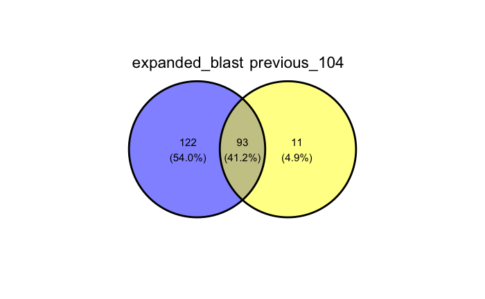

```r
p104 <- read_tsv("../../output/XP_028889033_homologs_combine_blast_stat.tsv", col_types = cols())
ggvenn(list(expanded_blast = dedup.merge$pid, previous_104 = p104$id))
```

```r
p104 %>% filter(!id %in% gsub("BN[0-9]*_", "", dedup.merge$pid)) %>% arrange(species)
```

| source | id | species | strain | e_value | query_cover | perc_ident | length |
| --- | --- | --- | --- | --- | --- | --- | --- |
| FungiDB | B9J08_004098 | Candida auris | B8441 | 8e-131 | NA | NA | 1247 |
| refseq | XP_447567.2 | Candida glabrata | CBS 138 | 3e-08 | 51 | 28.31 | 1771 |
| refseq | XP_445977.1 | Candida glabrata | CBS 138 | 2e-06 | 55 | 28.36 | 965 |
| FungiDB | CPAR2_600430 | Candida parapsilosis | CDC317 | 1e-08 | NA | NA | 1429 |
| FungiDB | CPAR2_806390 | Candida parapsilosis | CDC317 | 5e-22 | NA | NA | 1640 |
| FungiDB | CPAR2_806420 | Candida parapsilosis | CDC317 | 2e-09 | NA | NA | 1714 |
| FungiDB | CLUG_05233 | Clavispora lusitaniae | ATCC 42720 | 6e-09 | NA | NA | 1442 |
| refseq | XP_001386379.2 | Scheffersomyces stipitis | CBS 6054 | 7e-38 | 57 | 34.01 | 501 |
| refseq | XP_001385882.2 | Scheffersomyces stipitis | CBS 6054 | 2e-32 | 57 | 32.76 | 580 |
| refseq | XP_001386404.2 | Scheffersomyces stipitis | CBS 6054 | 5e-29 | 57 | 32.85 | 555 |

[output cut: 1 more lines]

> - The four *S. stipitis* sequences have been replaced by the new assembly
> - The *C. auris*, *C. glabrata*, *C. parasilosis* and *Clavispora lusitaniae* sequences are in fact all present in the new list, just under different IDs

### 9. Identify the PF11765 domain

Use HMMER to identify the location of the PF11765 domain. The hmm model was downloaded from the pfam database on 2022-05-04. Run the following command in `02-blast` directory.

```
hmmscan --noali --domE 1e-3 \
  -o 20220504-hmmscan.log \
  --domtblout output/20220506-expanded-blast-combined-PF11765-hmmscan.txt \
  data/HMM-profile/Hyphal_reg_CWP.hmm \
  output/20220506-expanded-blast-combined-homologs.faa
```

Read the result

```r
hmm.header <- c("target", "tacc", "tlen", "pid", "pacc", "slen", "full.evalue", "full.score", "full.bias",
                "num", "of", "c.evalue", "i.evalue", "domain.score", "domain.bias",
                "hmm.from", "hmm.to", "ali.from", "ali.to", "env.from", "env.to", "acc")
hmm <- read_table("../../output/20220506-expanded-blast-combined-PF11765-hmmscan.txt",
                  comment = "#", col_names = hmm.header, col_types = cols()) %>%
  mutate(sid = pid, pid = gsub("BN[0-9]*_", "", pid) %>% gsub("1_1$", "", .)) %>%
  select(sid, pid, num, of, i.evalue:env.to)
dedup.merge %>% filter(!pid %in% hmm$pid)
```

| source | query | sid | slen | pComplete | tID | tComplete | species | strain | qcovs | pident | evalue | staxid | pid | name |
| --- | --- | --- | --- | --- | --- | --- | --- | --- | --- | --- | --- | --- | --- | --- |
| RefSeq | Caur_Hil1 | ref\|XP_003959960.1\| | 3196 | no-right | XM_003959911 | no-ends | Kazachstania africana | CBS 2517 | 57 | 34.0 | 3.88e-10 | 1071382 | XP_003959960.1 | XP_003959960.1_Kazachstania_africana |
| RefSeq | Cgla_Hyr1 | gb\|QHS65618.1\| | 4497 |  | NA | NA | Candida glabrata | CBS 138 | 96 | 29.6 | 1.12e-16 | 5478 | QHS65618.1 | QHS65618.1_Candida_glabrata |

Curious why `hmmscan` didn’t identify the PF11765 domain in the two sequences, I submitted the same sequence file to [`Batch CD-search`](https://www.ncbi.nlm.nih.gov/Structure/bwrpsb/bwrpsb.cgi), which uses the RPS-BLAST to search a collection of protein sequences for matches to a set of profile matrices. It is the reverse of the PSI-BLAST.

```r
cdsearch <- read_tsv("../../output/20220509-expanded-blast-combined-pfam-cd-search-output.txt", skip = 7,
                     col_types = cols()) %>%
  filter(grepl("Hyphal", `Short name`)) %>%
  mutate(sid = str_match(Query, ">([a-zA-Z0-9_.]*) ")[,2],
         pid = gsub("BN[0-9]*_", "", sid) %>% gsub("1_1$", "", .)) %>%
  select(sid, pid, everything(), -Query)
cdsearch %>% filter(pid %in% setdiff(dedup.merge$pid, hmm$pid)) %>% select(-sid)
```

| pid | Hit type | PSSM-ID | From | To | E-Value | Bitscore | Accession | Short name | Incomplete | Superfamily |
| --- | --- | --- | --- | --- | --- | --- | --- | --- | --- | --- |
| XP_003959960.1 | superfamily | 403079 | 61 | 324 | 1.97446e-26 | 112.708 | cl13246 | Hyphal_reg_CWP superfamily | - | - |
| QHS65618.1 | specific | 403079 | 21 | 332 | 6.79330e-42 | 158.547 | pfam11765 | Hyphal_reg_CWP | - | cl13246 |

> Both sequences did have a match, although one of them has a “superfamily” level match, suggesting that no hits exceed the domain level E-value, but multiple hits met the “non-specific” criteria. Not sure why hmmscan didn’t pick up the domain in the *C. glabrata* sequence though

Merge the CD-Search and HMMSCAM results into one. I’m using the envelope coordinates from `hmmscan` rather than the alignment coordinates. According to [PFam documentation](https://pfam-docs.readthedocs.io/en/latest/glossary.html#alignment-coordinates), the envelope coordinates reflect the region where the match has been *probabilistically* determined to lie. It will be slightly wider than the alignment.

```r
hmm.cd <- cdsearch %>% filter(grepl("Hyphal_reg_CWP", `Short name`)) %>%
  select(sid, pid, cd.type = `Hit type`, cd.incom = Incomplete, cd.from = From, cd.to = To) %>%
  full_join(select(hmm, sid, pid, ali.from, ali.to, env.from, env.to)) %>%
  mutate(cd.len = cd.to - cd.from + 1,
         ali.len = ali.to - ali.from + 1,
         env.len = env.to - env.from + 1)
hmm.cd %>% group_by(pid) %>% filter(n() > 1) %>% select(-sid, -ends_with("to"))
```

| pid | cd.type | cd.incom | cd.from | ali.from | env.from | cd.len | ali.len | env.len |
| --- | --- | --- | --- | --- | --- | --- | --- | --- |
| XP_024712318.1 | specific | - | 14 | 15 | 12 | 305 | 310 | 315 |
| XP_024712318.1 | specific | - | 14 | 1305 | 1303 | 305 | 305 | 309 |
| XP_024712318.1 | specific | - | 1308 | 15 | 12 | 296 | 310 | 315 |
| XP_024712318.1 | specific | - | 1308 | 1305 | 1303 | 296 | 305 | 309 |
| XP_003671892.1 | specific | - | 12 | 12 | 10 | 312 | 316 | 318 |
| XP_003671892.1 | specific | - | 12 | 726 | 704 | 312 | 63 | 143 |
| NADE0s03e00110g | superfamily | - | 41 | 39 | 14 | 320 | 149 | 183 |
| NADE0s03e00110g | superfamily | - | 41 | 67 | 59 | 320 | 295 | 308 |

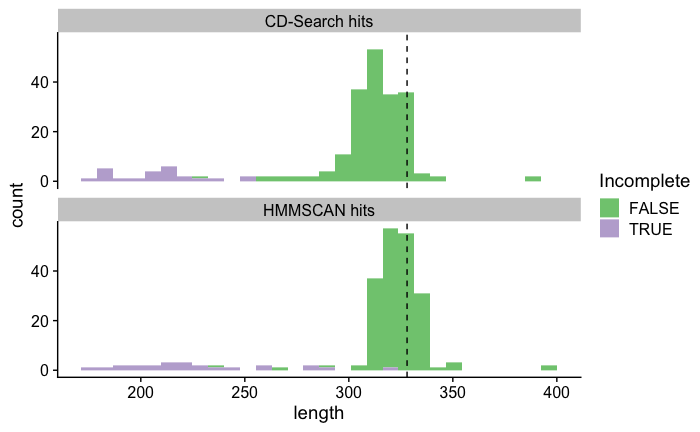

```r
domain.final <- hmm.cd %>%
  # remove the short hit and duplicates due to the join operation, but save the rows where hmmscan didn't find a match
  filter(is.na(ali.from) | (abs(ali.from - cd.from) < 1000 & ali.len > 100)) %>%
  filter(!(pid == "NADE0s03e00110g" & ali.from == 39)) # remove the overlapping entry
domain.final %>%
  pivot_longer(c(cd.len, env.len), values_to = "length", names_to = "method") %>%
  mutate(method = factor(method, levels = c("cd.len", "env.len"), labels = c("CD-Search hits", "HMMSCAN hits"))) %>%
  ggplot(aes(x = length)) +
  geom_histogram(aes(fill = cd.incom != "-"), bins = 30) +
  geom_vline(xintercept = 328, linetype = 2) +
  scale_fill_brewer("Incomplete", type = "qual") +
  facet_wrap(~method, nrow = 2, ) + theme_cowplot()
```

> Some are incomplete matches.

| sid | pid | cd.type | cd.incom | cd.from | cd.to | ali.from | ali.to | env.from | env.to | cd.len | ali.len | env.len |
| --- | --- | --- | --- | --- | --- | --- | --- | --- | --- | --- | --- | --- |
| XP_018710224.1 | XP_018710224.1 | specific | N | 1 | 216 | 2 | 223 | 1 | 226 | 216 | 222 | 226 |
| XP_006687291.1 | XP_006687291.1 | specific | C | 18 | 220 | 17 | 214 | 12 | 225 | 203 | 198 | 214 |
| XP_001523310.1 | XP_001523310.1 | specific | C | 13 | 193 | 12 | 193 | 11 | 197 | 181 | 182 | 187 |
| XP_001526001.1 | XP_001526001.1 | specific | C | 13 | 193 | 12 | 193 | 11 | 196 | 181 | 182 | 186 |
| XP_006684153.1 | XP_006684153.1 | specific | C | 11 | 207 | 11 | 207 | 9 | 207 | 197 | 197 | 199 |
| XP_018712348.1 | XP_018712348.1 | superfamily | C | 1 | 180 | 1 | 192 | 1 | 199 | 180 | 192 | 199 |
| XP_018709279.1 | XP_018709279.1 | superfamily | C | 1 | 176 | 1 | 176 | 1 | 176 | 176 | 176 | 176 |
| XP_018714230.1 | XP_018714230.1 | superfamily | C | 14 | 197 | 13 | 197 | 11 | 197 | 184 | 185 | 187 |
| XP_018710763.1 | XP_018710763.1 | superfamily | N | 6 | 256 | 6 | 255 | 1 | 256 | 251 | 250 | 256 |
| XP_003958180.1 | XP_003958180.1 | superfamily | N | 9 | 217 | 8 | 222 | 2 | 224 | 209 | 215 | 223 |

[output cut: 14 more lines]

Write the coordinates into a BED formatted file for extracting the sequences.

```r
domain.final %>%
  mutate(
    # if hmm hits are not available, use cd-search hit coordinates, with 3 bp expansion on both sides
    # note that BED format is 0-based for the start position
    from = ifelse(is.na(env.from), cd.from - 3 - 1, env.from - 1),
    to = ifelse(is.na(env.to), cd.to + 3, env.to)) %>%
  select(seq = sid, from, to) %>%
  # the following statement is to remove the second PF11765 domain from one protein for the purpose of gene tree
  group_by(seq) %>%
  filter(from == min(from)) %>%
  write_tsv(file = "../../output/20220512-expanded-blast-combined-homologs-PF11765.BED", col_names = FALSE)
```

Also write a version with the long name and not removing the second domain from the one sequence, for the purpose of plotting and calculating sequence length - PF11765

```r
domain.final %>%
  mutate(
    from = ifelse(is.na(env.from), cd.from - 3 - 1, env.from - 1),
    to = ifelse(is.na(env.to), cd.to + 3, env.to)) %>%
  select(seq = pid, from, to) %>% # select pid for merging with dedup.merge
  left_join(select(dedup.merge, seq = pid, name), by = "seq") %>%
  ungroup %>% select(name, from, to) %>%
  write_tsv(file = "../../output/20220623-expanded-blast-combined-homologs-PF11765-longname.BED", col_names = FALSE)
```

To extract the sequence matches to the PF11765 profile, execute the following shell command

```
seqtk subseq 20220506-expanded-blast-combined-homologs.faa \
             20220512-expanded-blast-combined-homologs-PF11765.BED  > \
             20220512-expanded-blast-combined-homologs-PF11765.faa
```

### 10. Rename the sequences for gene tree reconstruction

To facilitate gene tree reconstruction, rename the sequence names in the form of ID_species_name, and get rid of the description

```r
renamer <- dedup.merge %>%
  # a bit complicated: in the sequence file, sequence names from Refseq sequences were modified
  # while sequences from GRYC were not
  mutate(id = ifelse(source == "RefSeq", pid, sid)) %>%
  select(id, name) %>%
  deframe()
myFastaRename <- function(file, out){
  input <- read.fasta(file, seqtype = "AA", as.string = TRUE)
  if(any(grepl(":", names(input)))){
    # deal with the seqtk output
    names(input) <- gsub(":.*$", "", names(input))
  }
  if(!all(names(input) %in% names(renamer))){
    warning("The following sequences were not found in the rename list:")
    print(setdiff(names(input), names(renamer)))
  }
  write.fasta(input, names = renamer[names(input)], file.out = out, nbchar = 5000)
}
```

```r
myFastaRename(file = "../../output/20220506-expanded-blast-combined-homologs.faa",
              out = "../../output/20220506-expanded-blast-combined-homologs-longname.faa")
myFastaRename(file = "../../output/20220512-expanded-blast-combined-homologs-PF11765.faa",
              out = "../../output/20220512-expanded-blast-combined-homologs-PF11765-longname.faa")
```

### 11. Obtain subtrees for the species included

This is for the latter gene tree reconcilation and plotting.

Output the species used as a single column text file:

```r
# after adding the GRYC species, we need to expand the sps.include list
# add S. cerevisiae for species tree illustrations
sps.final <- c(unique(dedup.merge$species), "Saccharomyces cerevisiae")
# convert the species names to the Shen 2018 name
sps.final.shen <- spsNameConvert %>%
  mutate(ncbi.name = species,
         shen2018 = word(gsub("_", " ", old_speceis_names), -2, -1)) %>%
  select(ncbi.name, shen2018, `Major clade`, Family, Genus) %>%
  filter(ncbi.name %in% sps.final)
cat("The following species are not present in the Shen 2018 list and need to be added later.")
```

```
The following species are not present in the Shen 2018 list and need to be added later.
```

```r
setdiff(sps.final, spsNameConvert$species)
```

```
[1] "Candida haemuloni"        "Candida duobushaemulonis" "Candida pseudohaemulonii"
```

```r
sps.final.shen$shen2018 %>% na.omit() %>% gsub(" ", "_", .) %>%
  write(file = paste0("data/", gsub("-", "", Sys.Date()), "-expanded-blast-species-list.txt"))
```

Get the species tree using [TreeHouse](https://github.com/JLSteenwyk/treehouse)

```r
# first install shiny and phytools package
shiny::runGitHub("treehouse", "JLSteenwyk")
```

I then manually added the missing species by editing the Newick file (without branch length version). The final result is shown below:

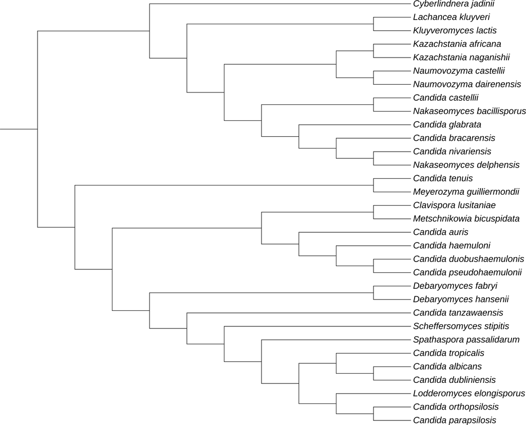

Also export the gene-to-species mapping for `generax`

```r
gene2sps.map <- dedup.merge %>%
  select(name, species) %>%
  # modify the two species names that differ between the gene names and species tree
  mutate(treeName = gsub(" ", "_", species))#treeName = case_when(
    #species == "Yamadazyma tenuis" ~ "Candida tenuis",
    #species == "Suhomyces tanzawaensis" ~ "Candida tanzawaensis",
    #TRUE ~ species),
    #treeName = gsub(" ", "_", treeName))

gene2sps.map %>%
  select(name, treeName) %>%
  write_tsv("data/20220516-expanded-blast-genes-to-species-map.tsv", col_names = FALSE)
```

Append the species list with additional information

```r
sps.patho <- read_tsv("data/20220518-expanded-blast-species-pathogen-info.txt", col_types = cols())
sps.summary <- dedup.merge %>%
  group_by(species, staxid) %>%
  summarize(
    total = n(),
    short = sum(slen < 500),
    shortIncompl = ifelse(
      any(is.na(pComplete)), NA,
      sum(pComplete %in% c("no-ends", "no-left", "no-right") & slen < 500)
    ),
    .groups = "drop"
  ) %>%
  add_row(species = "Saccharomyces cerevisiae",
          staxid = "559292",
          total = 0, short = 0, shortIncompl = NA) %>%
  left_join(sps.patho, by = "species") %>%
  arrange(desc(total))
sps.summary %>% select(-staxid)
```

| species | total | short | shortIncompl | pathogen | reference |
| --- | --- | --- | --- | --- | --- |
| Metschnikowia bicuspidata | 29 | 27 | 10 | crustacean | wikipedia |
| Candida tropicalis | 16 | 2 | 0 | human | NA |
| Candida parapsilosis | 15 | 10 | 0 | human | NA |
| Candida glabrata | 13 | 0 | 0 | human | NA |
| Candida albicans | 12 | 0 | 0 | human | NA |
| Candida haemuloni | 12 | 0 | 0 | human | NA |
| Candida pseudohaemulonii | 12 | 0 | 0 | human | NA |
| Candida dubliniensis | 11 | 0 | 0 | human | NA |
| Candida duobushaemulonis | 11 | 0 | 0 | human | NA |
| Kazachstania africana | 10 | 4 | 0 | no report | NA |

[output cut: 23 more lines]

Query the taxonomy database for lineage information for each species

```r
taxon <- entrez_fetch(db = "taxonomy", id = sps.summary$staxid, rettype = "xml") %>%
  XML::xmlToList()
names(taxon) <- sps.summary$species
```

Parse the taxonomy information

```r
sps.lin <- lapply(taxon, function(x) {
  bind_rows(x$LineageEx) %>% tail(-10) %>% filter(Rank != "species")
  }) %>%
  bind_rows(.id = "species")
write_tsv(sps.lin, "data/20220518-expanded-blast-species-taxonomy.tsv")
```

Write species info to file

```r
spsInfo <- sps.lin %>%
  filter(Rank == "family") %>%
  select(species, family = ScientificName) %>%
  mutate(treeName = gsub(" ", "_", species)) %>%
    #treeName = case_when(
    #species == "Yamadazyma tenuis" ~ "Candida tenuis",
    #species == "Suhomyces tanzawaensis" ~ "Candida tanzawaensis",
    #TRUE ~ species),
    #treeName = gsub(" ", "_", treeName)) %>%
  right_join(sps.summary, by = "species")

write_tsv(spsInfo, file = "data/20220518-expanded-blast-species-info.tsv")
```